# Estadística Descriptiva con Datos Cualitativos

Ramon Ceballos

27/1/2021

# Estudio de bebés recién nacidos

Instalad y cargad el paquete **MASS**. Encontraréis una tabla de datos llamada **birthwt** sobre factores que pueden incidir en el peso de los niños al nacer.

PREGUNTAS

1. Con str() y head(), explorad la estructura, y con help(), mirad el significado de cada variable.

```r
#cargo la librería MASS
library(MASS)

#Exploro la tabla de datos
str(birthwt)
```

```
## 'data.frame':    189 obs. of  10 variables:
##  $ low  : int  0 0 0 0 0 0 0 0 0 0 ...
##  $ age  : int  19 33 20 21 18 21 22 17 29 26 ...
##  $ lwt  : int  182 155 105 108 107 124 118 103 123 113 ...
##  $ race : int  2 3 1 1 1 3 1 3 1 1 ...
##  $ smoke: int  0 0 1 1 1 0 0 0 1 1 ...
##  $ ptl  : int  0 0 0 0 0 0 0 0 0 0 ...
##  $ ht   : int  0 0 0 0 0 0 0 0 0 0 ...
##  $ ui   : int  1 0 0 1 1 0 0 0 0 0 ...
##  $ ftv  : int  0 3 1 2 0 0 1 1 1 0 ...
##  $ bwt  : int  2523 2551 2557 2594 2600 2622 2637 2637 2663 2665 ...
```

```r
#Se observan 10 variables numéricas (int)

#Observo las 4 primeras filas
head(birthwt,4)
```

|  | low | age | lwt | race | smoke | ptl | ht | ui | ftv | bwt |
| --- | --- | --- | --- | --- | --- | --- | --- | --- | --- | --- |
| 85 | 0 | 19 | 182 | 2 | 0 | 0 | 0 | 1 | 0 | 2523 |
| 86 | 0 | 33 | 155 | 3 | 0 | 0 | 0 | 0 | 3 | 2551 |
| 87 | 0 | 20 | 105 | 1 | 1 | 0 | 0 | 0 | 1 | 2557 |
| 88 | 0 | 21 | 108 | 1 | 1 | 0 | 0 | 1 | 2 | 2594 |

```r
tail(birthwt)
```

|  | low | age | lwt | race | smoke | ptl | ht | ui | ftv | bwt |
| --- | --- | --- | --- | --- | --- | --- | --- | --- | --- | --- |
| 78 | 1 | 14 | 101 | 3 | 1 | 1 | 0 | 0 | 0 | 2466 |
| 79 | 1 | 28 | 95 | 1 | 1 | 0 | 0 | 0 | 2 | 2466 |
| 81 | 1 | 14 | 100 | 3 | 0 | 0 | 0 | 0 | 2 | 2495 |
| 82 | 1 | 23 | 94 | 3 | 1 | 0 | 0 | 0 | 0 | 2495 |
| 83 | 1 | 17 | 142 | 2 | 0 | 0 | 1 | 0 | 0 | 2495 |
| 84 | 1 | 21 | 130 | 1 | 1 | 0 | 1 | 0 | 3 | 2495 |

2. Calcula una tabla de frecuencias relativas marginales de los pares (raza de la madre, peso inferior a 2.5 kg o no) que permita ver si la raza de la madre influye en el peso del bebé.

```r
#Guardo el data frame birthwt en el parámetro data
data = birthwt

#Frecuencias relativas de la raza para los recien nacidos de peso mayor o menor a 2.5 kg
Race_Low = prop.table(table(data$race, data$low),margin = 1)

#Cambio el nombre de las filas y columnas
colnames(Race_Low) = c("peso > 2.5 kgs", "peso < 2.5 kgs")
rownames(Race_Low) = c("white","black","other")

round(Race_Low,2)
```

```
##
##         peso > 2.5 kgs peso < 2.5 kgs
##   white           0.76           0.24
##   black           0.58           0.42
##   other           0.63           0.37
```

```r
#En la raza blanca el 76% de los recien nacidos pesan más de 2.5 kgs mientras que el 24% pesan menos de 2.5 kgs.

#En la raza negra el 58% de los recien nacidos pesan más de 2.5 kgs mientras que el 42% pesan menos de 2.5 kgs.

#En otras razas el 63% de los recien nacidos pesan más de 2.5 kgs mientras que el 37% pesan menos de 2.5 kgs.

#Debido a la variabilidad de porcentajes según la raza podemos concluir que la raza puede llegara influir en el peso final del recien nacido
```

3. Dibuja un diagrama de mosaico de la tabla del ejercicio anterior.

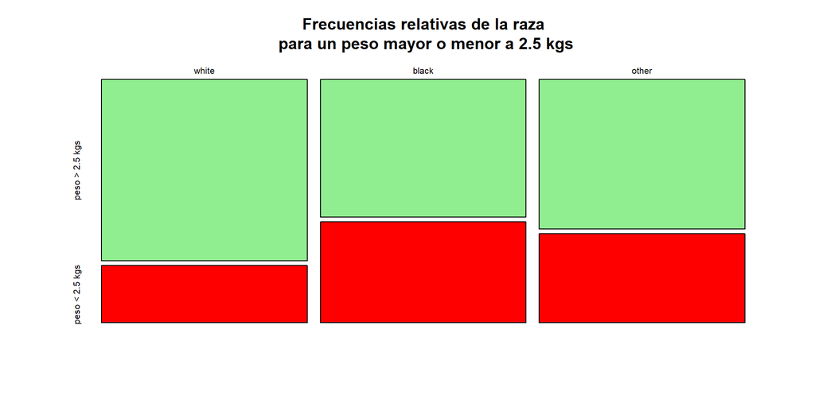

```r
plot(Race_Low,
     color =c("lightgreen" , "red"),
     main = "Frecuencias relativas de la raza\n para un peso mayor o menor a 2.5 kgs")
```

4. Dibuja un diagrama bidimensional de barras, con las barras organizadas en bloques, que permita visualizar la información de los ejercicios anteriores. Aprovecha para nombres adecuados a los bloques, colores a las barras, y añadir una leyenda que explique qué representa cada barra.

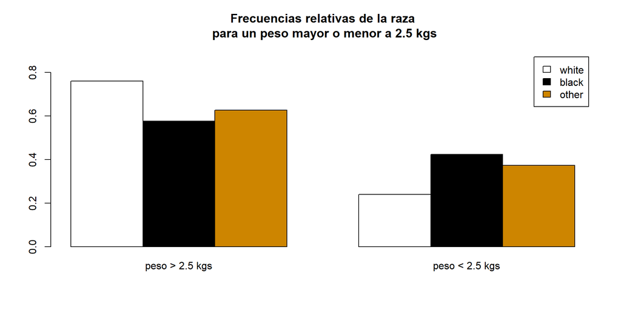

```r
barplot(Race_Low,
        beside =TRUE,
        col =c("white","black","orange3"),
        ylim = c(0,0.9),
        legend.text = TRUE,
        main = "Frecuencias relativas de la raza\n para un peso mayor o menor a 2.5 kgs")
```

5. ¿Se puede obtener alguna conclusión de la tabla y el diagrama de barras anterior? Argumenta tu respuesta

**Si se pueden obtener conclusiones a partir de las gráficas de los ejercicios 3 y 4. Más del 50% de los recien nacidos pesan más de 2.5 kgs con independencia de la raza, no obstante, los recien nacidos de madres de raza blanca presentan una mayor probabilidad respecto a la raza negra y otras razas**

6. Repite los cuatro ejercicios anteriores para los pares (madre fumadora o no, peso inferior a 2.5 kg o no) y para los pares (madre hipertensa o no, peso inferior a 2.5 kg o no.

```r
Smoke_Low = prop.table(table(data$smoke, data$low),margin = 1)
#Cambio el nombre de las filas y columnas
colnames(Smoke_Low) = c("peso > 2.5 kgs", "peso < 2.5 kgs")
#0 es no fumadora y 1 es fumadora
rownames(Smoke_Low) = c("Non smoker","Smoker")

round(Smoke_Low,2)
```

```
##
##              peso > 2.5 kgs peso < 2.5 kgs
##   Non smoker           0.75           0.25
##   Smoker               0.59           0.41
```

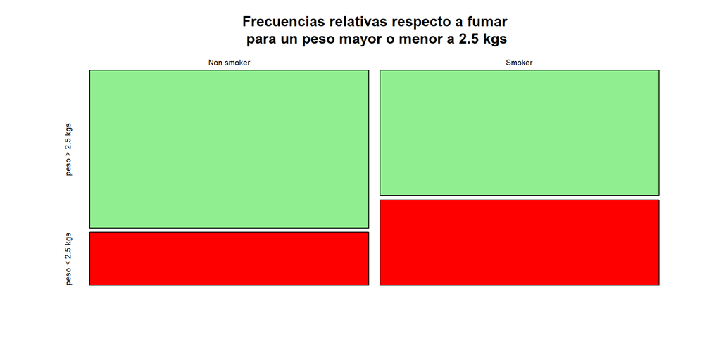

```r
#Gráfica de mosaico
plot(Smoke_Low,
     color =c("lightgreen" , "red"),
     main = "Frecuencias relativas respecto a fumar\n para un peso mayor o menor a 2.5 kgs")
```

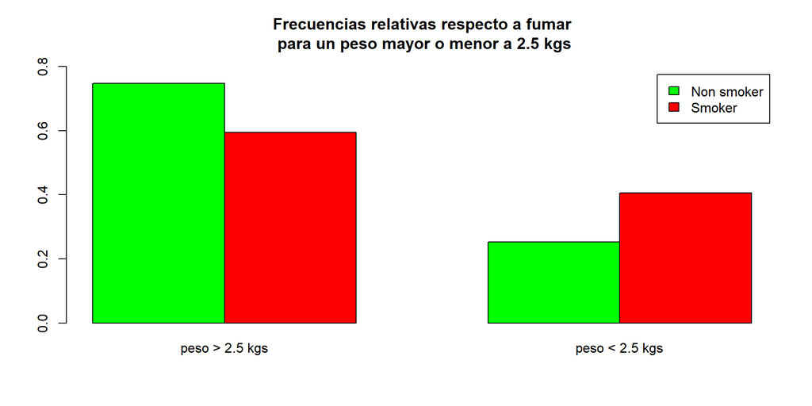

```r
#Gráfica de barras
barplot(Smoke_Low,
        beside =TRUE,
        col =c("green","red"),
        ylim = c(0,0.8),
        legend.text = TRUE,
        main = "Frecuencias relativas respecto a fumar\n para un peso mayor o menor a 2.5 kgs")
```

```r
#Se observa que en las mujeres que fumaron durante el embarazo tienen una mayor probabilidad (41%) de que el recien nacido pese menos de 2.5 kgs, respecto a las embarazadas que no fumaron (25%).
```

```r
Ht_Low = prop.table(table(data$ht, data$low),margin = 1)
#Cambio el nombre de las filas y columnas
colnames(Ht_Low) = c("peso > 2.5 kgs", "peso < 2.5 kgs")
#0 es no fumadora y 1 es fumadora
rownames(Ht_Low) = c("Non hypertensive","Hypertensive")

round(Ht_Low,2)
```

```
##
##                    peso > 2.5 kgs peso < 2.5 kgs
##   Non hypertensive           0.71           0.29
##   Hypertensive               0.42           0.58
```

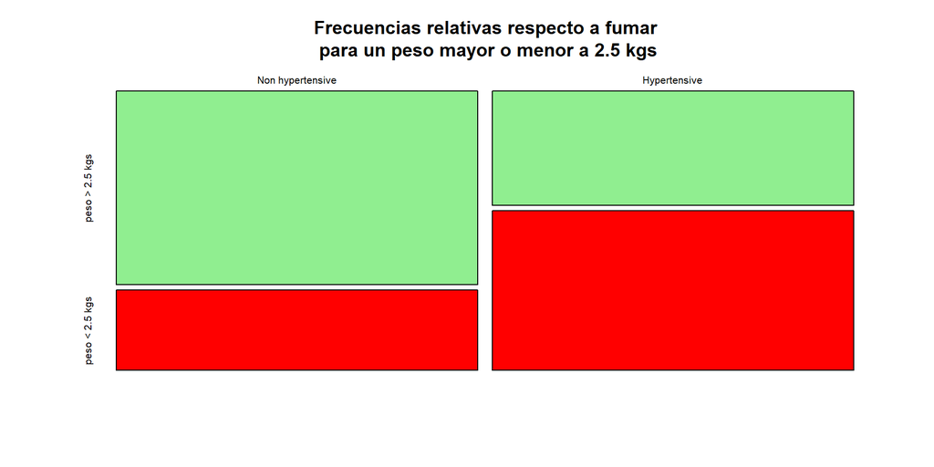

```r
#Gráfica de mosaico
plot(Ht_Low,
     color =c("lightgreen" , "red"),
     main = "Frecuencias relativas respecto a fumar\n para un peso mayor o menor a 2.5 kgs")
```

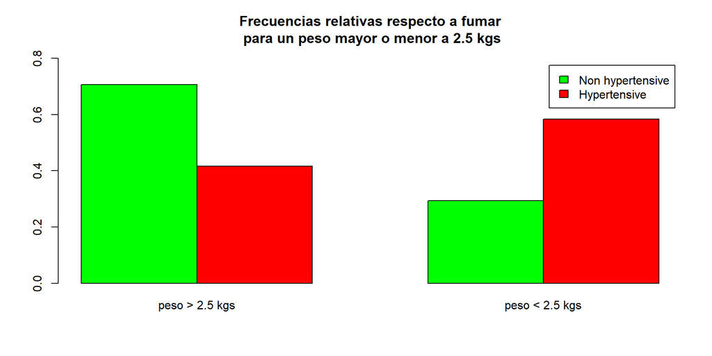

```r
#Gráfica de barras
barplot(Ht_Low,
        beside =TRUE,
        col =c("green","red"),
        ylim = c(0,0.8),
        legend.text = TRUE,
        main = "Frecuencias relativas respecto a fumar\n para un peso mayor o menor a 2.5 kgs")
```

```r
#Se observa que en las mujeres hipertensas tienen una mayor probabilidad (58%) de que el recien nacido pese menos de 2.5 kgs, respecto a las embarazadas no hipertensas (29%).
```

7. Calcula una tabla de frecuencias relativas marginales de las ternas (raza de la madre, madre fumadora o no, peso inferior a 2.5 kg o no) que permita ver si la raza de la madre y su condición de fumadora o no fumadora influyen en el peso del bebé.

```r
#Convierto en factores las tres variables implicadas en el estudio y le cambio el nombre a los niveles
#race
data$race =as.factor(data$race)
levels(data$race) = c("White","Black","Others")
#smoke
data$smoke =as.factor(data$smoke)
levels(data$smoke) = c("Non smoker","Smoker")
#low
data$low =as.factor(data$low)
levels(data$low) = c("peso > 2.5 kgs", "peso < 2.5 kgs")

#Guardo la tabla de frecuencia marginales de la raza y fumadores respecto al peso mayor o no de 2.5kgs
Race_Smoke_Low = prop.table(table(data$race,data$smoke,data$low), margin = c(1,2))

round(ftable(Race_Smoke_Low),2)
```

```
##                    peso > 2.5 kgs peso < 2.5 kgs
##
## White  Non smoker            0.91           0.09
##        Smoker                0.63           0.37
## Black  Non smoker            0.69           0.31
##        Smoker                0.40           0.60
## Others Non smoker            0.64           0.36
##        Smoker                0.58           0.42
```

8. Dibuja un diagrama de mosaico de la tabla del ejercicio anterior.

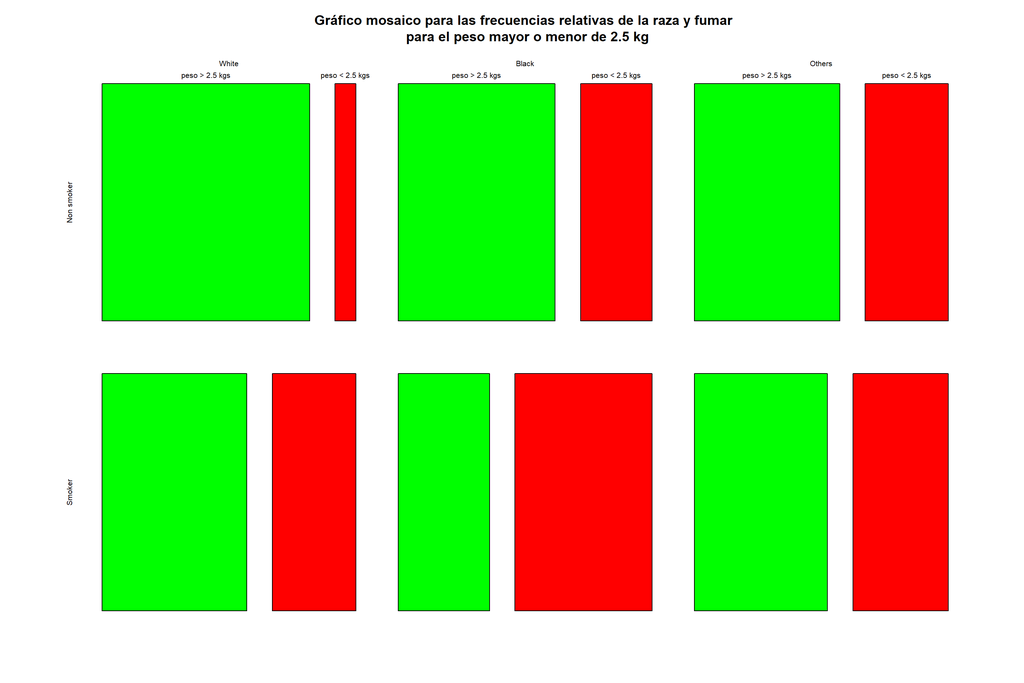

```r
plot(Race_Smoke_Low, col=c("green","red"),
     main = "Gráfico mosaico para las frecuencias relativas de la raza y fumar \n para el peso mayor o menor de 2.5 kg")
```